# Visualization Assignment 3

# Data visualization and the fight against crime

### Submitted by Eric Salmon, Bret Shindel, Fernanda De La O, Lorraine Williams

## Abstract

This exploration aims to assist Chicago law enforcement on more ways to more effectively allocate resources to areas and situations that have proven to be of higher crime potential based upon transit crime and weather data.

It is based upon data downloaded from the City of Chicago's open data website and contains crime records from 2012 that have been combined with community area information, weather and transit ride density for the day of the crime in question.

We would like to give special consideration to the excellent work already submitted by:

- Heather Steich (data sourcing and cleansing)
- Kristen Guy (initial data exploration).

## How could Chicago law enforcement benefit from this analysis?

Crime in Chicago has been tracked by the Chicago Police Department's Bureau of Records since the beginning of the 20th century. The city's overall crime rate, especially the violent crime rate, is substantially higher than the US average.

In 2012, the City of Chicago took the very unusual step of cutting the Chicago Police Department’s (CPD) budget when the city eliminated 1200 vacant positions despite persistent problems with street violence in many communities in Chicago.

The closing of three police district stations and the merging of officers to nearby districts followed the reduction in budgeted positions at the CPD. During this same time period, Chicago experienced an unseasonably warm winter, which contributed significantly to a single year rise in homicides in 2012.

It is vitally important for policy decisions that will cost taxpayers hundreds of millions to billions of dollars be evidence based and include a thorough public discussion about the pros and cons involved.

Prior data analysis concluded that, if the city were to hire a thousand more officers it would, at a minimum, cost community members over $1 billion over the next ten years for both salary & benefits. For two thousand more officers over the same time period we would be spending over $2.1 billion. Also, if the city is going to make a decision to hire hundreds or thousands of new officers then they need to understand the cost not just for a single year (the first year of employment for officers is also the least expensive year) but over the long-term.

By providing insight into what crime is more likely to occur, where and (potentially) when, then the CPD would be able to hire and deploy officers in a more targetted and cost effective fashion.

## How weather conditions affect crime in the Chicago area

Many factors were taken into consideration when analysing the Chicago-based crime, arrest rate and weather data. Amongst these were dew point temperature, wind speed and even changes in sea level.

In summary, temperature does appear to be a reasonably useful indicator of crime, with respect to what types of crime will be committed, and whether or not an arrest will be successfully made. It is therefore recommended that:

- weather forecasts are consulted and staffing in high crime areas increased on warmer days
- a survey is conducted to determine whether the uniforms chafe in the nether regions ;)

## The relationship between public transport and crime rates

The major factors taken into consideration for this section were number and type of CTA rides i the Chicago area on week days versus weekends.

The analysis performed indicates that the average number of CTA crimes on Saturday is similar to the average number of crimesthat occur on weekdays. However, the comparison of distributions lends evidence to the idea that Sunday is different from all other days of the week, with respect to CTA crime. Due to this, we recommend that the the agency consider re-allocating some of the CTA security resources from Sundays to other days.

## Demographic influences

Analysis indicates that areas with a higher percentage of people of non-working age contributes most to the arrest rate with the city of Austin out-performing all other areas in Chicago by a wide margin.

Austin is on the higher side of the distribution of the Hardship Index and evidence exists that Hardship Index values and per capita income are cofactors in crime

The lower the unemployment rate, the lower the amount of crime in the area.

# Supporting Statistical Analysis & Data Visualizations

## Importing Libraries and Loading the Data

```python
import numpy as np
import pandas as pd
import matplotlib as mpl
import matplotlib.pyplot as plt
import seaborn as sns
import statsmodels.api as sm
import scipy
```

```python
pd.set_option('display.max_columns', 40)
pd.set_option('display.max_rows', 20)
```

```python
# setting df names based upon merging of different code bases
Data = pd.read_csv("Steich_HW1_DataSet.csv", low_memory=False)
Data.head(3)
```

|  | Unnamed: 0 | ID | Date | Day of Week | Primary Type | Description | Location Description | Arrest | Domestic | Latitude | Longitude | Community Area | CA Name | Area Prop Housing Crowded | Area Prop Households Below Poverty | Area Prop Age>16 Unemployed | Area Prop Age>25 w/o HS Diploma | Area Prop Age<18 or Age>64 | Area Per Capita Income | Hardship Index | CST | Max TempF | Min TempF | Max Dew PtF | Min DewPtF | Max Humidity | Min Humidity | Max Sea Lvl PresIn | Min Sea Lvl PresIn | … |
| --- | --- | --- | --- | --- | --- | --- | --- | --- | --- | --- | --- | --- | --- | --- | --- | --- | --- | --- | --- | --- | --- | --- | --- | --- | --- | --- | --- | --- | --- | --- |
| 0 | 0 | 8421479 | 2012-01-01 | Sunday | BATTERY | SIMPLE | STREET | 0 | 0 | 41.814873 | -87.688296 | 58 | Brighton Park | 0.144 | 0.236 | 0.139 | 0.451 | 0.393 | 13089 | 84 | 2012-01-01 | 44 | 29 | 36 | 16 | 85 | 56 | 30.07 | 29.52 | … |
| 1 | 1 | 8421469 | 2012-01-01 | Sunday | BATTERY | SIMPLE | HOTEL/MOTEL | 1 | 0 | 41.872709 | -87.624188 | 32 | Loop | 0.015 | 0.147 | 0.057 | 0.031 | 0.135 | 65526 | 3 | 2012-01-01 | 44 | 29 | 36 | 16 | 85 | 56 | 30.07 | 29.52 | … |
| 2 | 2 | 8421462 | 2012-01-01 | Sunday | BATTERY | SIMPLE | APARTMENT | 1 | 0 | 41.765425 | -87.578129 | 43 | South Shore | 0.028 | 0.311 | 0.200 | 0.140 | 0.357 | 19398 | 55 | 2012-01-01 | 44 | 29 | 36 | 16 | 85 | 56 | 30.07 | 29.52 | … |

```python
print("Number of observations:", Data.shape[0])
print("Number of features:", Data.shape[1])
```

```
Number of observations: 297978
Number of features: 35
```

This is a very robust dataset. It has many observations and many different features that we can analyze. We have a lot of data to work with. We also have many features that can be discrete categorical, and continuous.

**Drop unnamed column**

```python
Data = Data.drop('Unnamed: 0', axis=1)
```

**Convert datetimes**

```python
Data['Date'] = pd.to_datetime(Data['Date'])
Data['CST'] = pd.to_datetime(Data['CST'])
```

**Drop rows**

```python
#Data = Data[Data.PrecipIn != 'T']
#Removing this column ^ takes away more than 40,000 observations.
```

# Crime Data Exploration

We are going to understand how crime has shaped itself, changed and adapted over the course of 2012. The following will exibit bar plots, time series analysis and more. Once we have a comprehansive understanding on the ways that crime is taking place in Chicago, we can explore its relationships toward other factors and determine methodologies to focus our resources and combat crime.

```python
from sklearn.preprocessing import LabelEncoder
class_le = LabelEncoder()
Crime_Type_Num = class_le.fit_transform(Data['Primary Type'].values)
Crime_Type_Num
```

```
array([2, 2, 2, ..., 5, 2, 3])
```

```python
Crime_Type_Dum = pd.get_dummies(Data['Primary Type'])
Crime_Type_Dum.head(3)
```

|  | ARSON | ASSAULT | BATTERY | BURGLARY | CRIM SEXUAL ASSAULT | CRIMINAL DAMAGE | CRIMINAL TRESPASS | DECEPTIVE PRACTICE | GAMBLING | HOMICIDE | INTERFERENCE WITH PUBLIC OFFICER | INTIMIDATION | KIDNAPPING | LIQUOR LAW VIOLATION | MOTOR VEHICLE THEFT | NARCOTICS | NON-CRIMINAL | NON-CRIMINAL (SUBJECT SPECIFIED) | OBSCENITY | OFFENSE INVOLVING CHILDREN | PROSTITUTION | PUBLIC INDECENCY | PUBLIC PEACE VIOLATION | ROBBERY | SEX OFFENSE | STALKING | THEFT | WEAPONS VIOLATION |
| --- | --- | --- | --- | --- | --- | --- | --- | --- | --- | --- | --- | --- | --- | --- | --- | --- | --- | --- | --- | --- | --- | --- | --- | --- | --- | --- | --- | --- |
| 0 | 0 | 0 | 1 | 0 | 0 | 0 | 0 | 0 | 0 | 0 | 0 | 0 | 0 | 0 | 0 | 0 | 0 | 0 | 0 | 0 | 0 | 0 | 0 | 0 | 0 | 0 | 0 | 0 |
| 1 | 0 | 0 | 1 | 0 | 0 | 0 | 0 | 0 | 0 | 0 | 0 | 0 | 0 | 0 | 0 | 0 | 0 | 0 | 0 | 0 | 0 | 0 | 0 | 0 | 0 | 0 | 0 | 0 |
| 2 | 0 | 0 | 1 | 0 | 0 | 0 | 0 | 0 | 0 | 0 | 0 | 0 | 0 | 0 | 0 | 0 | 0 | 0 | 0 | 0 | 0 | 0 | 0 | 0 | 0 | 0 | 0 | 0 |

```python
Crime_Type_Numbers = Data['Primary Type'].value_counts()
Crime_Type_Numbers.head()
```

```
THEFT              70582
BATTERY            54450
NARCOTICS          34931
CRIMINAL DAMAGE    34662
BURGLARY           22147
Name: Primary Type, dtype: int64
```

```python
%matplotlib inline

sns.set_context('poster')
sns.mpl.rc("figure", figsize=(12,6))
```

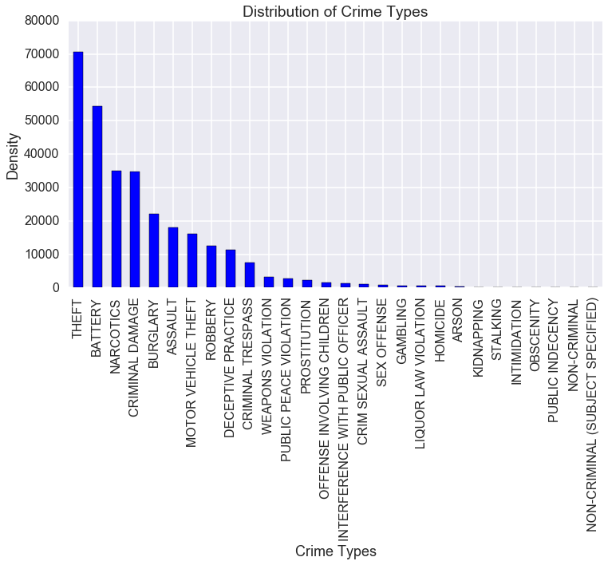

```python
Crime_Type_Numbers.plot.bar()

plt.title('Distribution of Crime Types', size=22)
plt.xlabel('Crime Types', size=18)
plt.ylabel('Density', size=18)
plt.show();
```

# Climate-Crime Analysis

## Creating an Enriched Climate Data Frame

```python
Climate = pd.DataFrame([])

Climate['TempF'] = Data[['Max TempF', 'Min TempF']].mean(axis=1)

Climate['DewPtF'] = Data[['Max Dew PtF', 'Min DewPtF']].mean(axis=1)

Climate['Humidity'] = Data[['Max Humidity', 'Min Humidity']].mean(axis=1)

Climate['SeaLvl'] = Data[['Max Sea Lvl PresIn', 'Min Sea Lvl PresIn']].mean(axis=1)

Climate['VisibilityMiles'] = Data[['Max Visibility Miles', 'Min Visibility Miles']].mean(axis=1)

Climate['MaxWindMPH'] = Data['Max Wind MPH']

Climate['PrecipIn'] = Data['PrecipIn']

Climate['CloudCover'] = Data['Cloud Cover']
```

```python
Climate.head(3)
```

[output not shown]

### Setting Median Climate Values

```python
med_temp = Climate.TempF.median()
med_sea = Climate.SeaLvl.median()
med_dew = Climate.DewPtF.median()
med_hum = Climate.Humidity.median()
med_wind = Climate.MaxWindMPH.median()
```

It is important to note that these are not the median values of 2012. These are simply the median values of the crime dataset in 2012, which will likely have differences with the true median. We would like to use the true median to plot it against our crime-climate medians, but unfortunately we are short on time. Instead, we will use these median values simply as a visible measure of if a particular occurance in our data, such as success ful arrests or a particular crime type, occurs above or below the dataset's median.

### Creating Climate-Crime Relationship Data Frames

```python
Climate_Arrest = pd.concat([Data.Arrest, Climate], axis=1, join_axes=[Climate.index])
Climate_Arrest.Arrest = Climate_Arrest.Arrest.astype('category')

Climate_Type = pd.concat([Data['Primary Type'], Climate], axis=1, join_axes=[Climate.index])
Climate_Type['Primary Type'] = Climate_Type['Primary Type'].astype('category')
```

## Climate Data Exploration

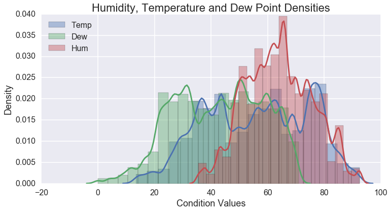

```python
sns.distplot(Climate.TempF, bins=20, label='Temp')
sns.distplot(Climate.DewPtF, bins=20, label='Dew')
sns.distplot(Climate.Humidity, bins=20, label='Hum')

plt.title('Humidity, Temperature and Dew Point Densities', size=22)
plt.xlabel('Condition Values', size=18)
plt.ylabel('Density', size=18)
plt.legend(loc='upper left')
plt.show();
```

```
''
```

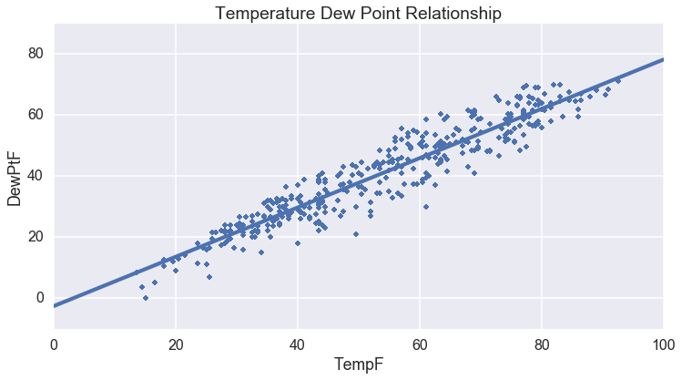

```python
sns.regplot(Climate_Arrest.TempF, Climate_Arrest.DewPtF)

plt.title('Temperature Dew Point Relationship');
```

Temperature and Dew Point have a positive relationship. This may be important to know for our future analyses.

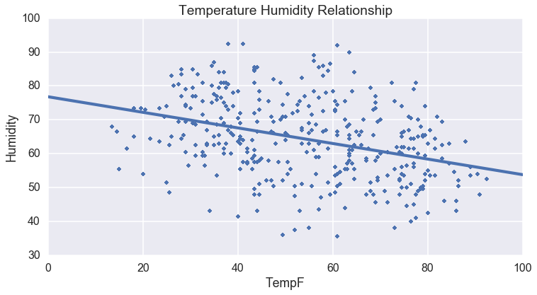

```python
sns.regplot(Climate_Arrest.TempF, Climate_Arrest.Humidity)

plt.title('Temperature Humidity Relationship');
```

Temperature and humidity have a weak negative relationship

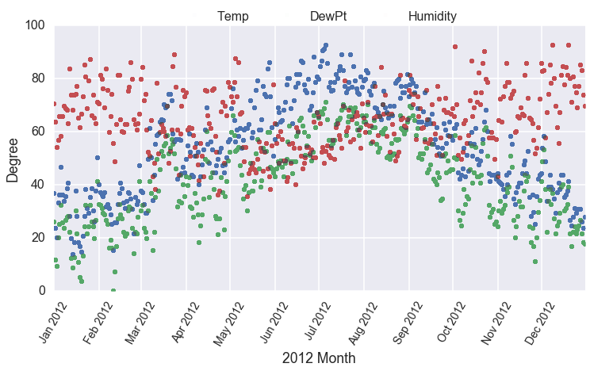

```python
plt.plot(Data.CST, Climate.TempF, '.', alpha=0.01, label='Temp')
plt.plot(Data.CST, Climate.DewPtF, '.', alpha=0.01, label='DewPt')
plt.plot(Data.CST, Climate.Humidity, '.', alpha=0.01, label='Humidity')

ax = plt.subplot(111)
ax.legend(loc='upper center', bbox_to_anchor=(0.5, 1.1), ncol=3, fancybox=True, shadow=False)

plt.xticks(rotation=60, size=14)
plt.xlabel('2012 Month')
plt.ylabel('Degree')
plt.show();
```

```python
Climate_Heat = Climate.pivot_table(values='TempF', index='VisibilityMiles', columns='CloudCover', aggfunc=np.median)
Climate_Heat.head()
```

| CloudCover VisibilityMiles | 0 | 1 | 2 | 3 | 4 | 5 | 6 | 7 | 8 |
| --- | --- | --- | --- | --- | --- | --- | --- | --- | --- |
| 3.5 | NaN | NaN | NaN | NaN | NaN | NaN | NaN | NaN | 35 |
| 4.0 | NaN | NaN | NaN | 44 | NaN | NaN | NaN | NaN | NaN |
| 4.5 | NaN | NaN | NaN | NaN | NaN | NaN | NaN | 28 | NaN |
| 5.0 | NaN | NaN | NaN | NaN | 61 | NaN | 68.5 | 58 | 56 |
| 5.5 | NaN | NaN | NaN | 91 | 30 | 82 | 79.0 | 37 | 41 |

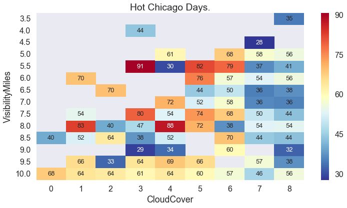

```python
sns.heatmap(Climate_Heat, cmap= 'RdYlBu_r', annot= True, fmt=',.0f', annot_kws={'fontsize':13})

plt.title('Hot Chicago Days.')
plt.show();
```

The model shows temperature seems to be increasing as cloud cover decreases. Does this surprise us? Probably not, because sunnlight raises the temperature. There is less data as visibility miles decreases, which also may explain why our medians become more extreme as our values increase on the y-axis.

# Exploring the Climate-Crime Relationship

Do changes in the climate of the Chicago area have a measurable impact on levels or types of crimes committed in various communities? It's very possible that this dimension of the dataset will yield no results, or on the contrary, we may find something marvelously interesting about some of the relationships we find.

We are going to approach this dataset starting from a broad relationship perspective, and narrow it down further into specific types of crimes and weather conditions, dates, and other features.

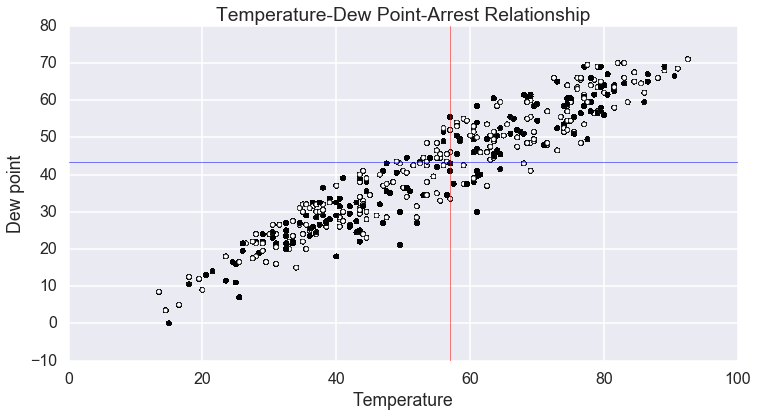

```python
ax = plt.subplot(111)
plt.scatter(Climate_Arrest.TempF, Climate_Arrest.DewPtF, c = Climate_Arrest.Arrest)
ax.axhline(y=med_dew, linewidth=1, color='b', linestyle='-', alpha=0.5)
ax.axvline(x=med_temp, linewidth=1, color='r', linestyle='-', alpha=0.5)

plt.title('Temperature-Dew Point-Arrest Relationship')
plt.ylabel('Dew point')
plt.xlabel('Temperature')
plt.show();
```

The datapoints certainly are not linearly seperable. However, I do notice that many arrest points seem to be clustered in particular areas. Perhaps these areas are data cluster spots (given that Chicago is often at that general temperature and dew point), or the weather conditions in these locations actually correlate with higher arrests? Or, there may simply be more weather records at these particular points, skewing the data in favor of more dense spots.

We want to get a sense of what climate features relate to rates of arrest, but we have several features, so how should we determine which features we should focus our visualizations on? We could make an educated guess based on our prior experiences and knowledge, but that unfortunately can lead to repetition of our efforts and missing critical links that we may not see. There is another way...

# Feature Reduction with Machine Learning Models

As we know, visualization is often used for the purpose of giving us an understanding of the data that we are working with. When you see a visualization, you should immediately get a sense of the relationships between different features. Unfortunately many features can lead to a lot of busy work for us, repeating visualizations over and over to get a sense of what analyses need to be done. Fortunately, there are tools to work around this.

## Principal Component Analysis (PCA)

Principal Component Analysis is a Feature Extraction method to reduce the number of important features in our dataser. It is an unsupervised learning algorithm, which means that it can model any type of (numerical) data without prior knowledge of its attributes. PCA helps identify patterns in data based on correlations between features. Essentially, PCA aims to find the directions of maximum variance in high dimensional data and projects it onto a new subspace with equal or fewer dimensions. The orthogonal axes (principal components) of the new subspace can be interpreted as the directions of maximum variance given the constraint that the new feature axes are orthogonal to each other.

PCA dimensions are highly sensitive to data scaling, so we need to standardize the features prior to PCA because the features were measured on different scales, and we want to assign equal importance to all features.

This will not be the full PCA, but we will use part of the process to assist us in determining which features are more helpful. We will standardize the data, construct a covariance matrix, obtain its eigenvalues and eigenvectors, and sort the eigenvalues by decreasing order to rank the eigenvectors.

```python
from sklearn.cross_validation import train_test_split
from sklearn.preprocessing import StandardScaler

#Convert dataframe values into correstponding X matrix and y vector
X, y = Climate_Arrest.iloc[:, 1:7].values, Climate_Arrest.iloc[:, 0].values

#Standardize the Matrix values to prepare for feature processing
sc = StandardScaler()
X_std = sc.fit_transform(X)
X_std
```

```
array([[-1.07518247, -1.07128635,  0.56266729, -1.10493203, -1.47596821,
         1.98562472],
       [-1.07518247, -1.07128635,  0.56266729, -1.10493203, -1.47596821,
         1.98562472],
       [-1.07518247, -1.07128635,  0.56266729, -1.10493203, -1.47596821,
         1.98562472],
       ...,
       [-1.56983177, -1.61670307,  0.47752683,  0.5079889 ,  0.21141618,
         0.15494877],
       [-1.56983177, -1.61670307,  0.47752683,  0.5079889 ,  0.21141618,
         0.15494877],
       [-1.56983177, -1.61670307,  0.47752683,  0.5079889 ,  0.21141618,
         0.15494877]])
```

```python
cov_mat = np.cov(X_std.T)
eigen_vals, eigen_vecs = np.linalg.eig(cov_mat)
print("\nEigenvalues: \n%s" % eigen_vals)
```

```
Eigenvalues:
[ 2.22394654  1.90238557  1.02087883  0.00673085  0.58176896  0.26430939]
```

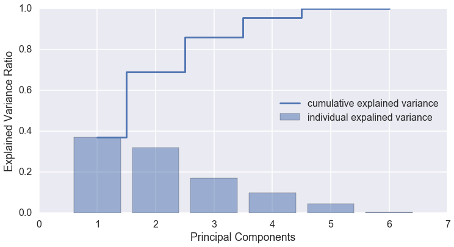

```python
tot = sum(eigen_vals)
var_exp = [(i/tot) for i in sorted(eigen_vals, reverse=True)]
cum_var_exp = np.cumsum(var_exp)

plt.bar(range(1, 7), var_exp, alpha=0.5, align='center', label='individual expalined variance')
plt.step(range(1, 7), cum_var_exp, where='mid', label='cumulative explained variance')
plt.ylabel('Explained Variance Ratio')
plt.xlabel('Principal Components')
plt.legend(loc='best')
plt.show()
```

Perhaps the cumulative explained variance measure is a waste of data ink, but I figure why not try and make the model look a little special?

So what does it tell us? Unfortunately due to its nature as an unsupervised learning algorithm, the PCA did not keep track of the names of each feature, so unless we proceed forward we have nothing to go off of. On a positive note, the visualization suggests to us that there are some features that could be relevant to telling us what weather conditions relate to rates of arrests. Let's procees ahead with another model, one that hopefully will retain the names of its features.

## Feature Reduction with Random Forest Model

We will change tactics and build a random forest model instead. The purpose of this model is similar to our goal before: we want to get an idea of what features (weather conditions) correlate most strongly with successful arrests.

In a random forests model, we can measure feature importance as the average impurity decrease computed from all decision trees in the forest without assuming if our data is linearly seperable or not (good news for us!). Conveniently, random forest in scikil-learn already collects feature importances. We will train a forest of 100 trees on our dataset and rank the features by their respective importance measures. Note that we don't need to standardize or normalize tree based models.

```python
from sklearn.ensemble import RandomForestClassifier

feat_labels = Climate_Arrest.columns[1:]

forest = RandomForestClassifier(n_estimators=100, random_state=0, n_jobs=1)
forest.fit(X, y)

importances = forest.feature_importances_
indices = np.argsort(importances)[::-1]

for f in range(X.shape[1]):
    print("(%2d) %-*s %f" % (f + 1, 30, feat_labels[f], importances[indices[f]]))
```

```
( 1) TempF                          0.203724
( 2) DewPtF                         0.187006
( 3) Humidity                       0.185105
( 4) SeaLvl                         0.184462
( 5) VisibilityMiles                0.156760
( 6) MaxWindMPH                     0.082943
```

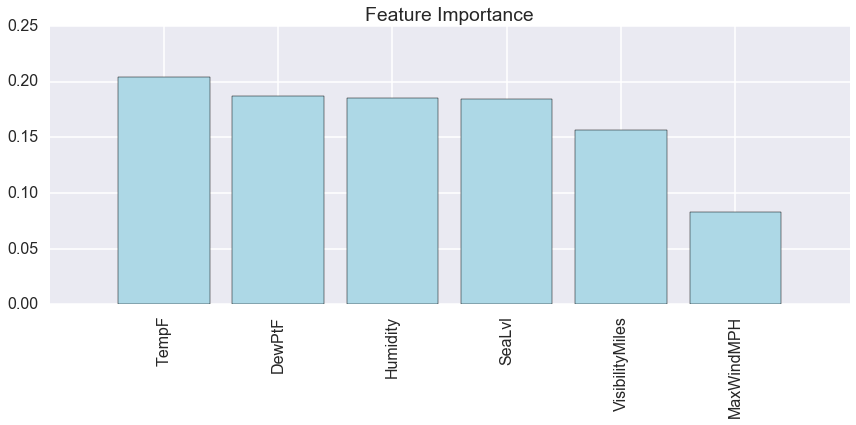

```python
plt.title('Feature Importance')

plt.bar(range(X.shape[1]), importances[indices], color='lightblue', align='center')

plt.xticks(range(X.shape[1]), feat_labels, rotation=90)
plt.xlim([-1, X.shape[1]])
plt.tight_layout()
plt.show();
```

There's another (not so) interesting part of this plot. Our features are ordered exactly the same way they are ordered in the dataframe. Is this a coincidence that our features line up this way? Or is there something off with out model? We will pull our data through one more model to see if there are any differences in its resukts.

## Sparse Solutions with L1 Regularization

Regularization is a very useful method to handle colinearity (high correlation among features). It's main use is for filtering out noise from data, and eventually prevent overfitting, but it can also be a useful feature reduction technique. L1 Regulatization as a specific regularization type that replaces the square of assigned weights by the sum of the absolute value of the weights. L1 yields sparse feature vectors; most feature weights will be zero. Sparsity can be useful if we have a high-dimensional dataset with many irrelevant features. In this sense, L1 regularization can be understood as a technique for feature selection.

We can use the scikit-learn library to model L1 regularization:

```python
from sklearn.linear_model import LogisticRegression
lr = LogisticRegression(penalty='l1', C=0.1)
lr.fit(X, y)
print('Accuracy:', lr.score(X, y))
```

```
Accuracy: 0.721271369027
```

72% accuracy isn't the greatest, but it can still be useful for what we're trying to accomplish (choose which features are most related to arrest rates).

However, I totally forgot, we want to standardize our values again for Regularization. Let's run the standardized X matrix back through the model and see how accurate it is.

```python
lr = LogisticRegression(penalty='l1', C=0.1)
lr.fit(X_std, y)
print('Accuracy:', lr.score(X_std, y))
```

```
Accuracy: 0.721271369027
```

Odd, it's exactly the same as before. It seems that standardization of our data didn't have an impact on the accuracy of our logistic regression. For the principal of modelling, we will proceed with the standardized matrix.

```python
lr.intercept_
```

```
array([-0.95118714])
```

```python
lr.coef_
```

```
array([[ 0.        , -0.04971912, -0.00582219,  0.00258261, -0.01144169,
        -0.00049428]])
```

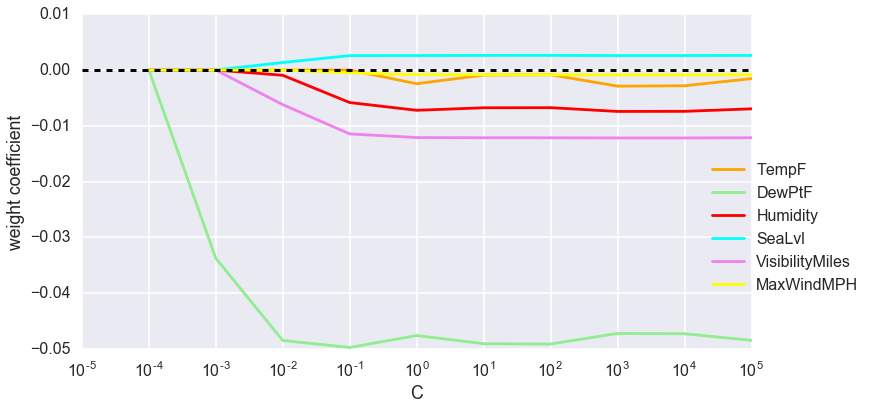

```python
fig = plt.figure()
ax = plt.subplot(111)
colors = ['orange', 'lightgreen', 'red', 'cyan', 'violet', 'yellow']
weights, params = [], []
for c in np.arange(-4, 6):
    lr = LogisticRegression(penalty='l1', C=10**c, random_state=0)
    lr.fit(X_std, y)
    weights.append(lr.coef_[0])
    params.append(10**c)
weights = np.array(weights)
for column, color in zip(range(weights.shape[1]), colors):
    plt.plot(params, weights[:, column], label=Climate.columns[column], color=color)
plt.axhline(0, color='black', linestyle='--', linewidth=3)
plt.xlim([10**(-5), 10**5])
plt.xlabel('C')
plt.ylabel('weight coefficient')
plt.xscale('log')
plt.legend(loc='upper left')
ax.legend(loc='upper center', bbox_to_anchor=(1.05, 0.6), ncol=1)
sns.set_context('poster')
plt.show()
```

Our visual tells us something quite different this time. The only feature with a positive weight coefficient is Sea Level. I also can see a big red flag with what this model is telling me: dew point and temperature are both positively correlated, yet the weight coefficient for dew point falls far below (in a relative perspective) temperature.

These models may prove useful in the future, but we will have to visualize our climate-crime relationship data without their guidance. We will interpret our results and compare it to the two models, and speculate on their accuracy. It should also be recognized that these models can be useful, but they are not perfect. Considering that climate and arrest rates probably have little in common, these models may simply be unable to help with such a low existing relationsuip.

# Exploring the Climate-Crime Relationship Cont.

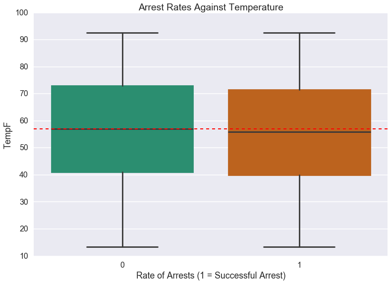

```python
ax = plt.subplot(111)
sns.boxplot(x = 'Arrest', y = 'TempF', data = Climate_Arrest, palette="Dark2")
ax.axhline(y=med_temp, linewidth=2, color='r', linestyle='--')

plt.title('Arrest Rates Against Temperature')
plt.xlabel('Rate of Arrests (1 = Successful Arrest)')
plt.show();
```

The difference is hardy noticeable, but it's there. Higher temperature seems to result in slightly fewer arrests being made. It's not a big difference, but it seems to suggest that something is happening when the temperature rises that is impacting the ability of our police force to make successful arrests.

Now that we know this, let's plot arrest rates against another variable to determine if our random forests model was effective at determining which features hold the highest relation to arrest rates.

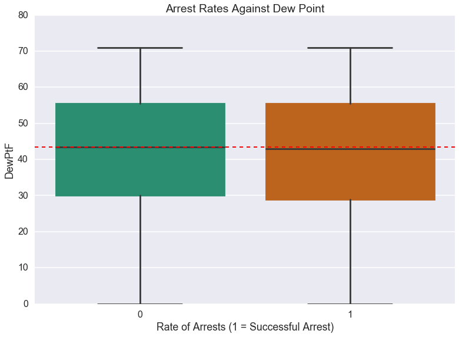

```python
ax = plt.subplot(111)
sns.boxplot(x = 'Arrest', y = 'DewPtF', data = Climate_Arrest, palette="Dark2")
ax.axhline(y=med_dew, linewidth=2, color='r', linestyle='--')

plt.title('Arrest Rates Against Dew Point')
plt.xlabel('Rate of Arrests (1 = Successful Arrest)')
plt.show();
```

Similar to temperature, higher dew point appears to be associated with a slightly lower rate of successful arrests. This makes sense with the regression plot we made above, which shows that temperature and dew point appear to be positively correlated. It also reinforces the indication of the random forests model, which identified dew point as one of the highest associators of arrest rates, and contradicts our regulatization model, which gave dew point the lowest eight coefficient. This is a reminder to us that models are useful, but are by no means perfect, and should never be assumed to be absolutely accurate.

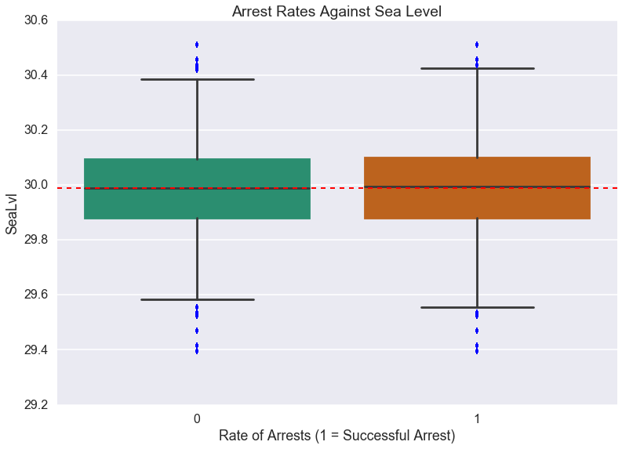

```python
ax = plt.subplot(111)
sns.boxplot(x = 'Arrest', y = 'SeaLvl', data = Climate_Arrest, palette="Dark2")
ax.axhline(y=med_sea, linewidth=2, color='r', linestyle='--')

plt.title('Arrest Rates Against Sea Level')
plt.xlabel('Rate of Arrests (1 = Successful Arrest)')
plt.show();
```

This is particularly interesting. Sea level should have no relationship to arrest rates at all, right? Well this boxplot tells us otherwise, as it shows there is a slight trend for higher rates of arrest when the sea level is higher. Unfortunately the difference is very small, and could very well be explained by random chance. One possible explanation is that a full moon, which has a gravitational pull that affects our sea levels, also affects levels of crime. There are many assumptions and even some studies that suggest a full moon has influence over facotrs such as rates of crime and suicide. We won't cite those studies or pull in related data, but it is important to think not only about how the features you're evaluating relate to each other, but also about how unknown features affect the ones that you are evaluating.

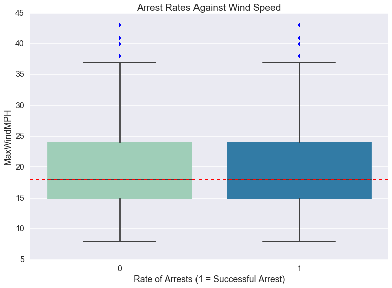

```python
ax = plt.subplot(111)
sns.boxplot(x = 'Arrest', y = 'MaxWindMPH', data = Climate_Arrest, palette="YlGnBu")
ax.axhline(y=med_wind, linewidth=2, color='r', linestyle='--')

plt.title('Arrest Rates Against Wind Speed')
plt.xlabel('Rate of Arrests (1 = Successful Arrest)')
plt.show();
```

Wind Speed is a feature that our random forest model indicated was not strongly associated with arrest rates. The plot does not contadict the model. There is no noticeable difference between the two arrest rates as far as we can visually see. We changed the pallette colors for this boxplot and the following ones, because unlike above, none of the others show any indication that they are associated with rates of arrest.

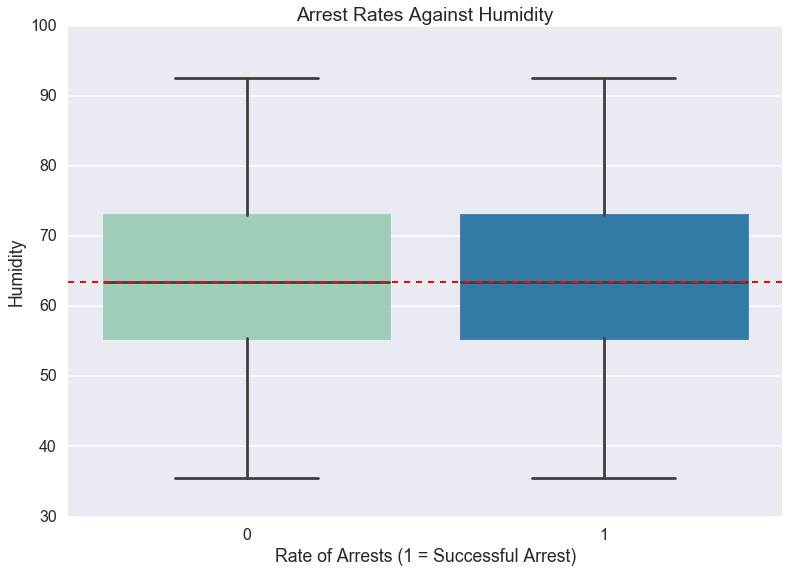

```python
ax = plt.subplot(111)
sns.boxplot(x = 'Arrest', y = 'Humidity', data = Climate_Arrest, palette="YlGnBu")
ax.axhline(y=med_hum, linewidth=2, color='r', linestyle='--')

plt.title('Arrest Rates Against Humidity')
plt.xlabel('Rate of Arrests (1 = Successful Arrest)')
plt.show();
```

## Visualizing Climate Relationships with Crime Types

Now we turn our attention to different types of crime, and how they are impacted by the overall climate.

```python
Climate_Type.head()
```

|  | Primary Type | TempF | DewPtF | Humidity | SeaLvl | VisibilityMiles | MaxWindMPH | CloudCover |
| --- | --- | --- | --- | --- | --- | --- | --- | --- |
| 0 | BATTERY | 36.5 | 26 | 70.5 | 29.795 | 6 | 33 | 7 |
| 1 | BATTERY | 36.5 | 26 | 70.5 | 29.795 | 6 | 33 | 7 |
| 2 | BATTERY | 36.5 | 26 | 70.5 | 29.795 | 6 | 33 | 7 |
| 3 | BURGLARY | 36.5 | 26 | 70.5 | 29.795 | 6 | 33 | 7 |
| 4 | CRIM SEXUAL ASSAULT | 36.5 | 26 | 70.5 | 29.795 | 6 | 33 | 7 |

## Fitting our Data Through the Random Forest Model

Our Random FOrest Model seemed to be fairly accurate at predicting which features hold relevance to arrest rates. We are going to pull our crime type data and clime data through the random forest model and determine if it is still helpful to us.

```python
X, y = Climate_Type.iloc[:, 1:8].values, Climate_Arrest.iloc[:, 0].values
sc = StandardScaler()
X_std = sc.fit_transform(X)
X_std

feat_labels = Climate_Type.columns[1:]

forest = RandomForestClassifier(n_estimators=1000, random_state=0, n_jobs=1)
forest.fit(X, y)

importances = forest.feature_importances_
indices = np.argsort(importances)[::-1]

for f in range(X.shape[1]):
    print("(%2d) %-*s %f" % (f + 1, 30, feat_labels[f], importances[indices[f]]))
```

```
( 1) TempF                          0.186737
( 2) DewPtF                         0.179727
( 3) Humidity                       0.163786
( 4) SeaLvl                         0.162659
( 5) VisibilityMiles                0.143448
( 6) MaxWindMPH                     0.087437
( 7) CloudCover                     0.076208
```

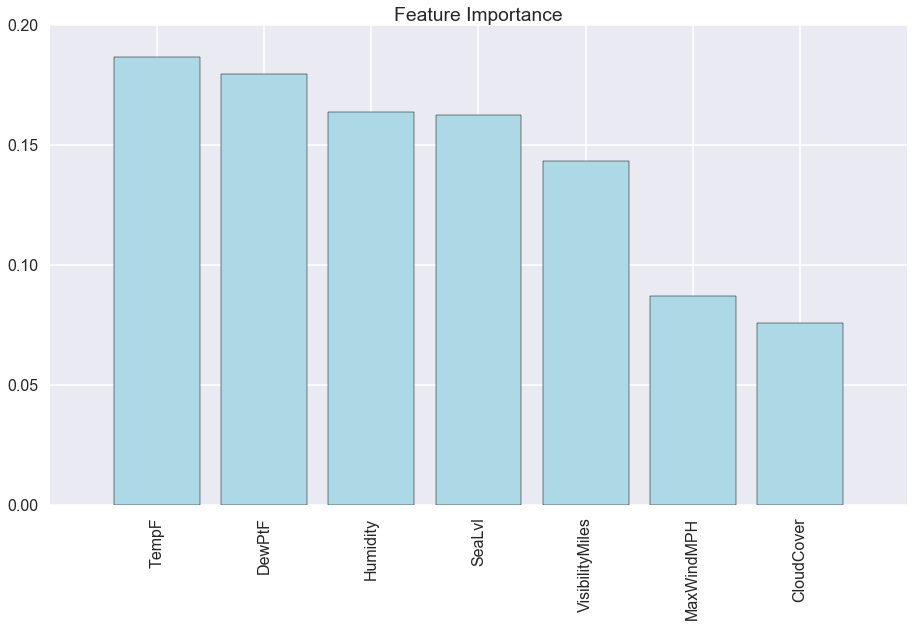

```python
plt.title('Feature Importance')

plt.bar(range(X.shape[1]), importances[indices], color='lightblue', align='center')

plt.xticks(range(X.shape[1]), feat_labels, rotation=90)
plt.xlim([-1, X.shape[1]])
plt.tight_layout()
plt.show();
```

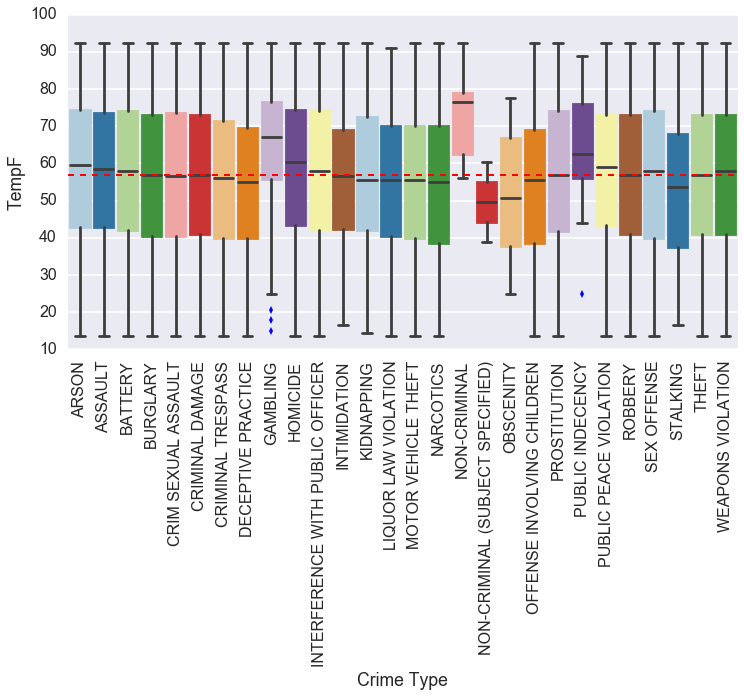

```python
sns.mpl.rc("figure", figsize=(12,6))
ax = plt.subplot(111)

sns.boxplot(x = 'Primary Type', y = 'TempF', data = Climate_Type, palette="Paired")
ax.axhline(y=med_temp, linewidth=2, color='r', linestyle='--')

plt.xlabel('Crime Type')
plt.xticks(rotation=90)
plt.show();
```

# Transport Crime Data Analysis

```python
# This first bit is just some exploration of the data

pd.options.display.max_columns = 999
crime.head()
```

|  | Unnamed: 0 | ID | Date | Day of Week | Primary Type | Description | Location Description | Arrest | Domestic | Latitude | Longitude | Community Area | CA Name | Area Prop Housing Crowded | Area Prop Households Below Poverty | Area Prop Age>16 Unemployed | Area Prop Age>25 w/o HS Diploma | Area Prop Age<18 or Age>64 | Area Per Capita Income | Hardship Index | CST | Max TempF | Min TempF | Max Dew PtF | Min DewPtF | Max Humidity | Min Humidity | Max Sea Lvl PresIn | Min Sea Lvl PresIn | … |
| --- | --- | --- | --- | --- | --- | --- | --- | --- | --- | --- | --- | --- | --- | --- | --- | --- | --- | --- | --- | --- | --- | --- | --- | --- | --- | --- | --- | --- | --- | --- |
| 0 | 0 | 8421479 | 2012-01-01 | Sunday | BATTERY | SIMPLE | STREET | 0 | 0 | 41.814873 | -87.688296 | 58 | Brighton Park | 0.144 | 0.236 | 0.139 | 0.451 | 0.393 | 13089 | 84 | 2012-01-01 | 44 | 29 | 36 | 16 | 85 | 56 | 30.07 | 29.52 | … |
| 1 | 1 | 8421469 | 2012-01-01 | Sunday | BATTERY | SIMPLE | HOTEL/MOTEL | 1 | 0 | 41.872709 | -87.624188 | 32 | Loop | 0.015 | 0.147 | 0.057 | 0.031 | 0.135 | 65526 | 3 | 2012-01-01 | 44 | 29 | 36 | 16 | 85 | 56 | 30.07 | 29.52 | … |
| 2 | 2 | 8421462 | 2012-01-01 | Sunday | BATTERY | SIMPLE | APARTMENT | 1 | 0 | 41.765425 | -87.578129 | 43 | South Shore | 0.028 | 0.311 | 0.200 | 0.140 | 0.357 | 19398 | 55 | 2012-01-01 | 44 | 29 | 36 | 16 | 85 | 56 | 30.07 | 29.52 | … |
| 3 | 3 | 8421444 | 2012-01-01 | Sunday | BURGLARY | HOME INVASION | APARTMENT | 0 | 0 | 41.732850 | -87.555470 | 46 | South Chicago | 0.047 | 0.298 | 0.197 | 0.266 | 0.411 | 16579 | 75 | 2012-01-01 | 44 | 29 | 36 | 16 | 85 | 56 | 30.07 | 29.52 | … |
| 4 | 4 | 8421811 | 2012-01-01 | Sunday | CRIM SEXUAL ASSAULT | NON-AGGRAVATED | STREET | 0 | 0 | 41.872709 | -87.624188 | 32 | Loop | 0.015 | 0.147 | 0.057 | 0.031 | 0.135 | 65526 | 3 | 2012-01-01 | 44 | 29 | 36 | 16 | 85 | 56 | 30.07 | 29.52 | … |

```python
crime['Primary Type'].value_counts()
```

```
THEFT                               70582
BATTERY                             54450
NARCOTICS                           34931
CRIMINAL DAMAGE                     34662
BURGLARY                            22147
ASSAULT                             17933
MOTOR VEHICLE THEFT                 16161
ROBBERY                             12435
DECEPTIVE PRACTICE                  11363
CRIMINAL TRESPASS                    7535
                                    ...
LIQUOR LAW VIOLATION                  548
HOMICIDE                              504
ARSON                                 455
KIDNAPPING                            230
STALKING                              190
INTIMIDATION                          147
OBSCENITY                              24
PUBLIC INDECENCY                       15
NON-CRIMINAL                            6
NON-CRIMINAL (SUBJECT SPECIFIED)        2
Name: Primary Type, dtype: int64
```

```python
pd.options.display.max_rows = 9
crime['Location Description'].value_counts()
```

```
STREET             72437
RESIDENCE          44117
SIDEWALK           38662
APARTMENT          37390
                   ...
LIQUOR STORE           1
CHURCH PROPERTY        1
CHA PARKING LOT        1
VESTIBULE              1
Name: Location Description, dtype: int64
```

```python
crime[crime['Location Description'] == 'BASEMENT']
```

|  | Unnamed: 0 | ID | Date | Day of Week | Primary Type | Description | Location Description | Arrest | Domestic | Latitude | Longitude | Community Area | CA Name | Area Prop Housing Crowded | Area Prop Households Below Poverty | Area Prop Age>16 Unemployed | Area Prop Age>25 w/o HS Diploma | Area Prop Age<18 or Age>64 | Area Per Capita Income | Hardship Index | CST | Max TempF | Min TempF | Max Dew PtF | Min DewPtF | Max Humidity | Min Humidity | Max Sea Lvl PresIn | Min Sea Lvl PresIn | … |
| --- | --- | --- | --- | --- | --- | --- | --- | --- | --- | --- | --- | --- | --- | --- | --- | --- | --- | --- | --- | --- | --- | --- | --- | --- | --- | --- | --- | --- | --- | --- |
| 144140 | 144140 | 20482 | 2012-06-26 | Tuesday | HOMICIDE | FIRST DEGREE MURDER | BASEMENT | 1 | 1 | 41.73051 | -87.598618 | 47 | Burnside | 0.068 | 0.33 | 0.186 | 0.193 | 0.427 | 12515 | 79 | 2012-06-26 | 83 | 56 | 54 | 44 | 78 | 28 | 30.09 | 29.94 | … |

```python
crime['Description'].value_counts()
```

```
SIMPLE                            33085
DOMESTIC BATTERY SIMPLE           28521
$500 AND UNDER                    27710
POSS: CANNABIS 30GMS OR LESS      17503
                                  ...
DELIVER CANNABIS TO PERSON <18        1
JUVENILE PIMPING                      1
RECKLESS HOMICIDE                     1
MANU/DELIVER:AMPHETAMINES             1
Name: Description, dtype: int64
```

### Chicago Transportation Agency crime

```python
crime['Primary Type'][crime['Location Description'].str.contains("CTA")].value_counts()
```

```
THEFT                  2296
DECEPTIVE PRACTICE     1590
BATTERY                 809
ROBBERY                 710
                       ...
STALKING                  3
PROSTITUTION              1
MOTOR VEHICLE THEFT       1
OBSCENITY                 1
Name: Primary Type, dtype: int64
```

Now, looking specifically for crime associated with public transit.

```python
cta = crime[crime['Location Description'].str.contains("CTA")]
cta.head()
```

|  | Unnamed: 0 | ID | Date | Day of Week | Primary Type | Description | Location Description | Arrest | Domestic | Latitude | Longitude | Community Area | CA Name | Area Prop Housing Crowded | Area Prop Households Below Poverty | Area Prop Age>16 Unemployed | Area Prop Age>25 w/o HS Diploma | Area Prop Age<18 or Age>64 | Area Per Capita Income | Hardship Index | CST | Max TempF | Min TempF | Max Dew PtF | Min DewPtF | Max Humidity | Min Humidity | Max Sea Lvl PresIn | Min Sea Lvl PresIn | … |
| --- | --- | --- | --- | --- | --- | --- | --- | --- | --- | --- | --- | --- | --- | --- | --- | --- | --- | --- | --- | --- | --- | --- | --- | --- | --- | --- | --- | --- | --- | --- |
| 95 | 95 | 8421823 | 2012-01-01 | Sunday | CRIMINAL DAMAGE | TO CITY OF CHICAGO PROPERTY | CTA TRAIN | 0 | 0 | 42.022063 | -87.674849 | 1 | Rogers Park | 0.077 | 0.236 | 0.087 | 0.182 | 0.275 | 23939 | 39 | 2012-01-01 | 44 | 29 | 36 | 16 | 85 | 56 | 30.07 | 29.52 | … |
| 105 | 105 | 8421544 | 2012-01-01 | Sunday | THEFT | $500 AND UNDER | CTA TRAIN | 0 | 0 | 41.830954 | -87.630703 | 34 | Armour Square | 0.057 | 0.401 | 0.167 | 0.345 | 0.383 | 16148 | 82 | 2012-01-01 | 44 | 29 | 36 | 16 | 85 | 56 | 30.07 | 29.52 | … |
| 122 | 122 | 8465516 | 2012-01-01 | Sunday | THEFT | POCKET-PICKING | CTA BUS | 0 | 0 | 41.931781 | -87.727593 | 21 | Avondale | 0.060 | 0.153 | 0.092 | 0.247 | 0.310 | 20039 | 42 | 2012-01-01 | 44 | 29 | 36 | 16 | 85 | 56 | 30.07 | 29.52 | … |
| 157 | 157 | 8421673 | 2012-01-01 | Sunday | CRIMINAL DAMAGE | TO PROPERTY | CTA PLATFORM | 0 | 0 | 41.886345 | -87.774857 | 25 | Austin | 0.063 | 0.286 | 0.226 | 0.244 | 0.379 | 15957 | 73 | 2012-01-01 | 44 | 29 | 36 | 16 | 85 | 56 | 30.07 | 29.52 | … |
| 183 | 183 | 8422885 | 2012-01-01 | Sunday | THEFT | POCKET-PICKING | CTA TRAIN | 0 | 0 | 41.903524 | -87.666742 | 24 | West Town | 0.023 | 0.147 | 0.066 | 0.129 | 0.217 | 43198 | 10 | 2012-01-01 | 44 | 29 | 36 | 16 | 85 | 56 | 30.07 | 29.52 | … |

```python
# Add column with total crimes per day

day = pd.DataFrame(cta.groupby(['Date'])['Date'].count())
day['Public Transit Crimes'] = day['Date']
day.drop('Date', axis=1, inplace=True)
day['Date'] = day.index
day.head()
```

| Date | Public Transit Crimes | Date |
| --- | --- | --- |
| 2012-01-01 | 20 | 2012-01-01 |
| 2012-01-02 | 12 | 2012-01-02 |
| 2012-01-03 | 11 | 2012-01-03 |
| 2012-01-04 | 15 | 2012-01-04 |
| 2012-01-05 | 16 | 2012-01-05 |

```python
cta2 = pd.merge(day, cta, how='inner')
days2 = cta2.drop_duplicates('Date')
```

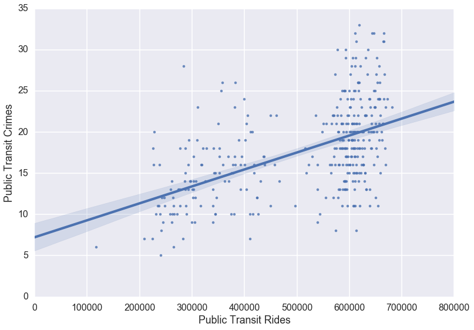

```python
sns.set_context('poster')
ax = sns.regplot(x = 'Public Transit Rides', y = 'Public Transit Crimes', data= days2)
```

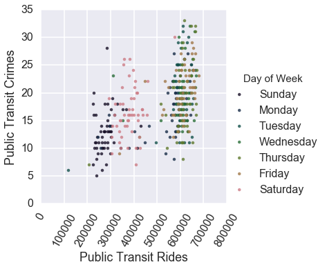

```python
g = sns.lmplot(x = 'Public Transit Rides', y = 'Public Transit Crimes', hue='Day of Week',
               data=days2, fit_reg=False, palette= sns.color_palette("cubehelix", 11))
plt.xticks(rotation=60)
plt.show()
```

This shows that there are definitely fewer riders on the weekends and that there seems to be fewer CTA crimes on Sundays than other days. But, it isn't clear that there are fewer CTA crimes on Saturdays than weekdays.

Most importantly, the drop in crimes on the weekends isn't close to proportional with the drop in ridership. What does this mean for passengers? That any individual rider has a higher likelihood of being the victim of a crime when riding public transit on the weekend.

```python
# Going to group and compare weekend days distribution/mean vs weekday (Levene and t-test)
# And/or compare Saturdays to Sundays.  This could help the CTA decide how many officers
# to dispatch on specific days of the week.
```

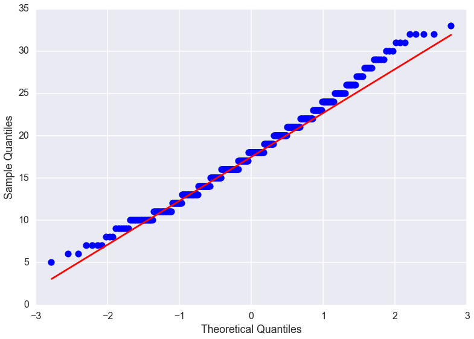

```python
# Checking to see if the distribution of crimes follows a normal distribution

sm.qqplot(days2['Public Transit Crimes'], line='q');
```

This shows that the distribution is approximately normal. This will guide the statistical test we use to determine if the mean and variance are different between days.

```python
# Separate weekends from weekdays to compare distributions

weekenddays = ['Saturday', 'Sunday']
weekdaydays = ['Monday', 'Tuesday', 'Wednesday', 'Thursday', 'Friday']
weekend = days2[days2['Day of Week'].isin(weekenddays)]
weekday = days2[days2['Day of Week'].isin(weekdaydays)]

sat = days2[days2['Day of Week'] == 'Saturday']
sun = days2[days2['Day of Week'] == 'Sunday']
```

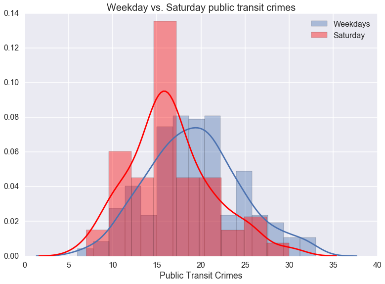

```python
sns.distplot(weekday['Public Transit Crimes'], label = 'Weekdays')
sns.distplot(sat['Public Transit Crimes'], label = 'Saturday', color = 'r')
# sns.distplot(sun['Public Transit Crimes'], label = 'Sunday', color = 'g')

plt.title("Weekday vs. Saturday public transit crimes", fontsize= 20)
plt.legend();
```

```python
scipy.stats.levene(sat['Public Transit Crimes'], weekday['Public Transit Crimes']).pvalue
```

```
0.16637363395876864
```

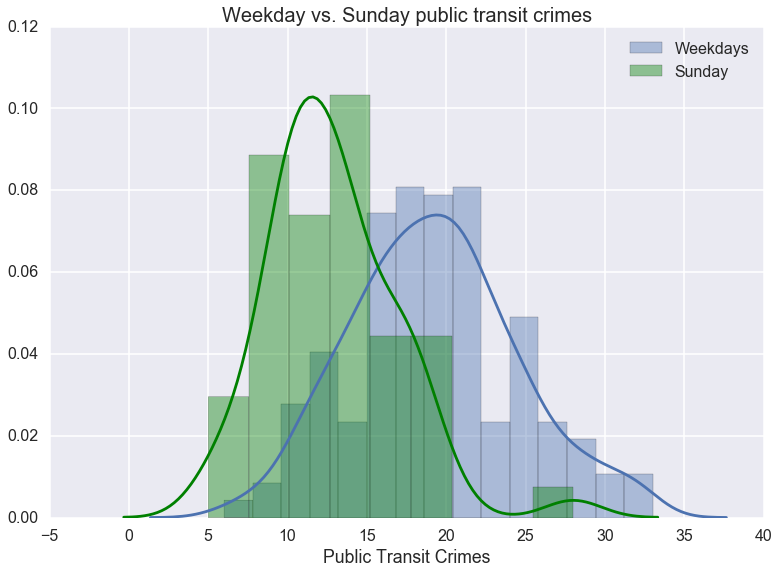

```python
sns.distplot(weekday['Public Transit Crimes'], label = 'Weekdays')
# sns.distplot(sat['Public Transit Crimes'], label = 'Saturday', color = 'r')
sns.distplot(sun['Public Transit Crimes'], label = 'Sunday', color = 'g')

plt.title("Weekday vs. Sunday public transit crimes", fontsize= 20)
plt.legend();
```

This comparison of distributions lends evidence to the idea that Sunday is different from all other days of the week, with respect to CTA crime. Let's now check this using statistical tests.

Levene's test for equality of variances will tell of if the variance of crime on Sunday is different from that of weekdays.

```python
scipy.stats.levene(sun['Public Transit Crimes'], weekday['Public Transit Crimes']).pvalue
```

```
0.014387910272047721
```

The means look clearly different on our plot above and the independent t-test will likely confirm this.

```python
scipy.stats.ttest_ind(sun['Public Transit Crimes'], weekday['Public Transit Crimes']).pvalue
```

```
2.8435885590685115e-15
```

With this p-value, we can very confididently say that there are fewer crimes on Sunday than on weekdays, on average.

Due to this, we recommend that allocation of CTA security resources be adjusted from Sundays to other days.

There is one very obvious outlier, where both public transit ridership and public transit crimes are very low.

```python
cta[cta['Public Transit Rides'] < 150000].head()
```

|  | Unnamed: 0 | ID | Date | Day of Week | Primary Type | Description | Location Description | Arrest | Domestic | Latitude | Longitude | Community Area | CA Name | Area Prop Housing Crowded | Area Prop Households Below Poverty | Area Prop Age>16 Unemployed | Area Prop Age>25 w/o HS Diploma | Area Prop Age<18 or Age>64 | Area Per Capita Income | Hardship Index | CST | Max TempF | Min TempF | Max Dew PtF | Min DewPtF | Max Humidity | Min Humidity | Max Sea Lvl PresIn | Min Sea Lvl PresIn | … |
| --- | --- | --- | --- | --- | --- | --- | --- | --- | --- | --- | --- | --- | --- | --- | --- | --- | --- | --- | --- | --- | --- | --- | --- | --- | --- | --- | --- | --- | --- | --- |
| 293635 | 293635 | 8943606 | 2012-12-25 | Tuesday | THEFT | $500 AND UNDER | CTA TRAIN | 0 | 0 | 41.990042 | -87.658917 | 77 | Edgewater | 0.041 | 0.182 | 0.092 | 0.097 | 0.238 | 33385 | 19 | 2012-12-25 | 33 | 25 | 25 | 18 | 85 | 64 | 30.32 | 30.11 | … |
| 293639 | 293639 | 8943863 | 2012-12-25 | Tuesday | BATTERY | SIMPLE | CTA TRAIN | 0 | 0 | 41.939918 | -87.653289 | 6 | Lake View | 0.011 | 0.114 | 0.047 | 0.026 | 0.170 | 60058 | 5 | 2012-12-25 | 33 | 25 | 25 | 18 | 85 | 64 | 30.32 | 30.11 | … |
| 293692 | 293692 | 8944101 | 2012-12-25 | Tuesday | THEFT | POCKET-PICKING | CTA PLATFORM | 0 | 0 | 41.978108 | -87.904123 | 76 | O'Hare | 0.036 | 0.154 | 0.071 | 0.109 | 0.303 | 25828 | 24 | 2012-12-25 | 33 | 25 | 25 | 18 | 85 | 64 | 30.32 | 30.11 | … |
| 293844 | 293844 | 8943791 | 2012-12-25 | Tuesday | SEX OFFENSE | ATT CRIM SEXUAL ABUSE | CTA TRAIN | 0 | 0 | 41.946489 | -87.718661 | 16 | Irving Park | 0.063 | 0.131 | 0.100 | 0.224 | 0.316 | 27249 | 34 | 2012-12-25 | 33 | 25 | 25 | 18 | 85 | 64 | 30.32 | 30.11 | … |
| 293919 | 293919 | 8944082 | 2012-12-25 | Tuesday | INTERFERENCE WITH PUBLIC OFFICER | OBSTRUCTING IDENTIFICATION | CTA PLATFORM | 1 | 0 | 41.721623 | -87.624701 | 49 | Roseland | 0.025 | 0.198 | 0.203 | 0.169 | 0.412 | 17949 | 52 | 2012-12-25 | 33 | 25 | 25 | 18 | 85 | 64 | 30.32 | 30.11 | … |

The outlier is Christmas day. This lends strong support to the notion of allowing MTA officers to spend time with their families on Christmas.

### Demographics - Arrests

```python
crime.head()
```

|  | Unnamed: 0 | ID | Date | Day of Week | Primary Type | Description | Location Description | Arrest | Domestic | Latitude | Longitude | Community Area | CA Name | Area Prop Housing Crowded | Area Prop Households Below Poverty | Area Prop Age>16 Unemployed | Area Prop Age>25 w/o HS Diploma | Area Prop Age<18 or Age>64 | Area Per Capita Income | Hardship Index | CST | Max TempF | Min TempF | Max Dew PtF | Min DewPtF | Max Humidity | Min Humidity | Max Sea Lvl PresIn | Min Sea Lvl PresIn | … |
| --- | --- | --- | --- | --- | --- | --- | --- | --- | --- | --- | --- | --- | --- | --- | --- | --- | --- | --- | --- | --- | --- | --- | --- | --- | --- | --- | --- | --- | --- | --- |
| 0 | 0 | 8421479 | 2012-01-01 | Sunday | BATTERY | SIMPLE | STREET | 0 | 0 | 41.814873 | -87.688296 | 58 | Brighton Park | 0.144 | 0.236 | 0.139 | 0.451 | 0.393 | 13089 | 84 | 2012-01-01 | 44 | 29 | 36 | 16 | 85 | 56 | 30.07 | 29.52 | … |
| 1 | 1 | 8421469 | 2012-01-01 | Sunday | BATTERY | SIMPLE | HOTEL/MOTEL | 1 | 0 | 41.872709 | -87.624188 | 32 | Loop | 0.015 | 0.147 | 0.057 | 0.031 | 0.135 | 65526 | 3 | 2012-01-01 | 44 | 29 | 36 | 16 | 85 | 56 | 30.07 | 29.52 | … |
| 2 | 2 | 8421462 | 2012-01-01 | Sunday | BATTERY | SIMPLE | APARTMENT | 1 | 0 | 41.765425 | -87.578129 | 43 | South Shore | 0.028 | 0.311 | 0.200 | 0.140 | 0.357 | 19398 | 55 | 2012-01-01 | 44 | 29 | 36 | 16 | 85 | 56 | 30.07 | 29.52 | … |
| 3 | 3 | 8421444 | 2012-01-01 | Sunday | BURGLARY | HOME INVASION | APARTMENT | 0 | 0 | 41.732850 | -87.555470 | 46 | South Chicago | 0.047 | 0.298 | 0.197 | 0.266 | 0.411 | 16579 | 75 | 2012-01-01 | 44 | 29 | 36 | 16 | 85 | 56 | 30.07 | 29.52 | … |
| 4 | 4 | 8421811 | 2012-01-01 | Sunday | CRIM SEXUAL ASSAULT | NON-AGGRAVATED | STREET | 0 | 0 | 41.872709 | -87.624188 | 32 | Loop | 0.015 | 0.147 | 0.057 | 0.031 | 0.135 | 65526 | 3 | 2012-01-01 | 44 | 29 | 36 | 16 | 85 | 56 | 30.07 | 29.52 | … |

```python
crime.iloc[1, 7]
```

```
1
```

```python
crimeb = crime.dropna()
demos = crimeb.iloc[:, 11:18]
demos.drop('Community Area', axis=1, inplace=True)
demos.drop('CA Name', axis=1, inplace=True)
demos.head()
```

|  | Area Prop Housing Crowded | Area Prop Households Below Poverty | Area Prop Age>16 Unemployed | Area Prop Age>25 w/o HS Diploma | Area Prop Age<18 or Age>64 |
| --- | --- | --- | --- | --- | --- |
| 0 | 0.144 | 0.236 | 0.139 | 0.451 | 0.393 |
| 1 | 0.015 | 0.147 | 0.057 | 0.031 | 0.135 |
| 2 | 0.028 | 0.311 | 0.200 | 0.140 | 0.357 |
| 3 | 0.047 | 0.298 | 0.197 | 0.266 | 0.411 |
| 4 | 0.015 | 0.147 | 0.057 | 0.031 | 0.135 |

### First model: Random Forest Model

We now used two statistical models in an attempt to determine which of the key demographic factors contribute most to arrests.

```python
from sklearn.cross_validation import train_test_split
from sklearn.preprocessing import StandardScaler

X, y = demos.values, crimeb.iloc[:, 7].values

sc = StandardScaler()
X_std = sc.fit_transform(X)
X_std
```

```
array([[ 2.41334415, -0.11495868, -0.38844632,  2.10477478,  0.53311861],
       [-1.02332179, -0.97484817, -1.44112615, -1.54118961, -2.64764136],
       [-0.67699111,  0.6096673 ,  0.39464478, -0.59497504,  0.08929164],
       ...,
       [-0.4105829 ,  2.10722765,  1.4216495 ,  0.66375076,  0.92763148],
       [-0.81019522, -0.97484817, -1.32558812, -0.69046458, -1.63670214],
       [ 0.25543763, -1.12943505, -0.88911112,  0.13421784, -0.41617797]])
```

```python
from sklearn.ensemble import RandomForestClassifier

feat_labels = demos.columns

forest = RandomForestClassifier(n_estimators=1000, random_state=0, n_jobs=1)
forest.fit(X, y)

importances = forest.feature_importances_
indices = np.argsort(importances)

for f in range(X.shape[1]):
    print("(%2d) %-*s %f" % (f +1, 40, feat_labels[f], importances[indices[f]]))
```

```
( 1) Area Prop Housing Crowded                0.144020
( 2) Area Prop Households Below Poverty       0.146525
( 3) Area Prop Age>16 Unemployed              0.158599
( 4) Area Prop Age>25 w/o HS Diploma          0.252383
( 5) Area Prop Age<18 or Age>64               0.298473
```

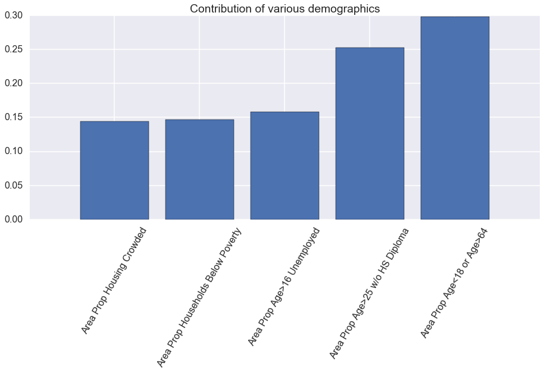

```python
plt.title('Contribution of various demographics')

plt.bar(range(X.shape[1]), importances[indices], align='center')

plt.xticks(range(X.shape[1]), feat_labels, rotation=60)
plt.xlim([-1,X.shape[1]])
plt.tight_layout()
plt.show()
```

This model seems to indicate that areas with a higher percentage of people of non-working age contributes most to the arrest rate. We are skeptical of this conclusion because it is contradicted by other, more straight-forward visualizations.

An eariler analysis of the data by Kristen Guy of the UOP Data Analytics Masters program indicates that % Adult Unemployment and % Below Povery corresponded more with greater levels of crime. This is not an apples-to-apples comparison, though because this model is for arrests, not crime.

In an attempt to provide further information, another statistical model was employed.

### Second model: L1 Sparse Regularization Model

```python
from sklearn.linear_model import LogisticRegression
lr = LogisticRegression(penalty='l1', C=0.1)
lr.fit(X, y)
print('Accuracy:', lr.score(X, y))
```

```
Accuracy: 0.72403497365
```

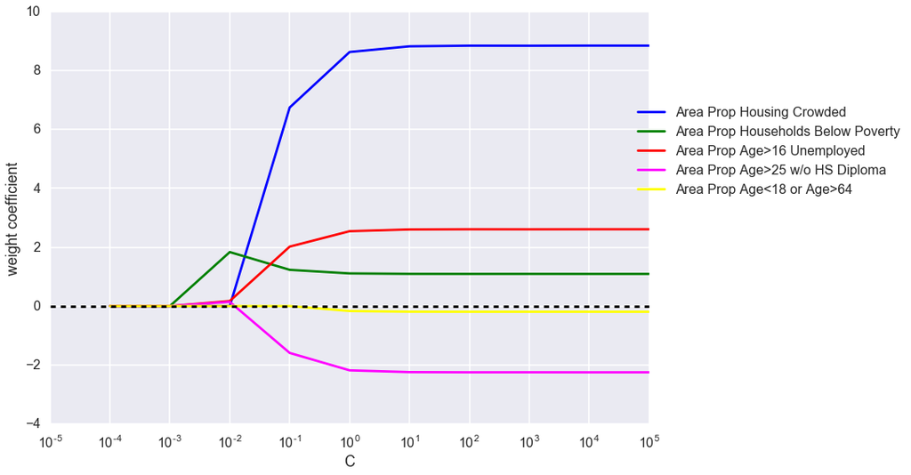

```python
fig = plt.figure()
ax = plt.subplot(111)
colors = ['blue', 'green', 'red', 'magenta', 'yellow']
weights, params = [], []
for c in np.arange(-4, 6):
    lr = LogisticRegression(penalty='l1', C=10**c, random_state=0)
    lr.fit(X, y)
    weights.append(lr.coef_[0])
    params.append(10**c)
weights = np.array(weights)
for column, color in zip(range(weights.shape[1]), colors):
    plt.plot(params, weights[:, column], label=demos.columns[column], color=color)
plt.axhline(0, color='black', linestyle='--', linewidth=3)
plt.xlim([10**(-5), 10**5])
plt.xlabel('C')
plt.ylabel('weight coefficient')
plt.xscale('log')
plt.legend(loc='upper left')
ax.legend(loc='upper center', bbox_to_anchor=(1.2, 0.8), ncol=1, fancybox=True)
sns.set_context('poster')
plt.show()
```

```python
demos_arrest = pd.concat([crimeb.Arrest, demos], axis=1, join_axes=[demos.index])
```

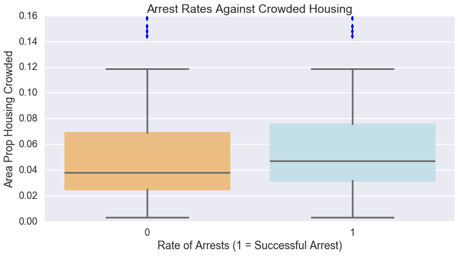

```python
sns.mpl.rc("figure", figsize=(12,6))
sns.boxplot(x = 'Arrest', y = 'Area Prop Housing Crowded', data = demos_arrest, palette="RdYlBu")

plt.title('Arrest Rates Against Crowded Housing')
plt.xlabel('Rate of Arrests (1 = Successful Arrest)')
plt.show();
```

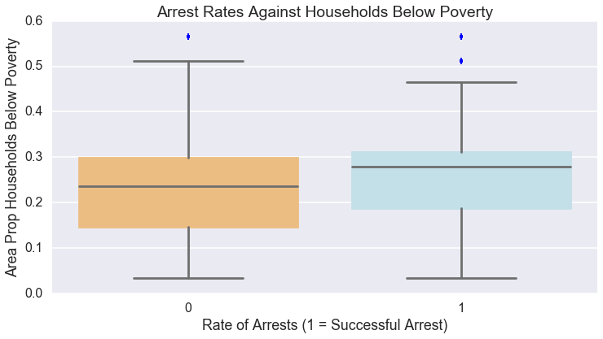

```python
sns.boxplot(x = 'Arrest', y = 'Area Prop Households Below Poverty', data = demos_arrest, palette="RdYlBu")

plt.title('Arrest Rates Against Households Below Poverty')
plt.xlabel('Rate of Arrests (1 = Successful Arrest)')
plt.show();
```

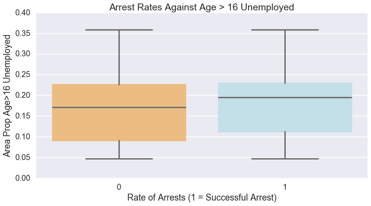

```python
sns.boxplot(x = 'Arrest', y = 'Area Prop Age>16 Unemployed', data = demos_arrest, palette="RdYlBu")

plt.title('Arrest Rates Against Age > 16 Unemployed')
plt.xlabel('Rate of Arrests (1 = Successful Arrest)')
plt.show();
```

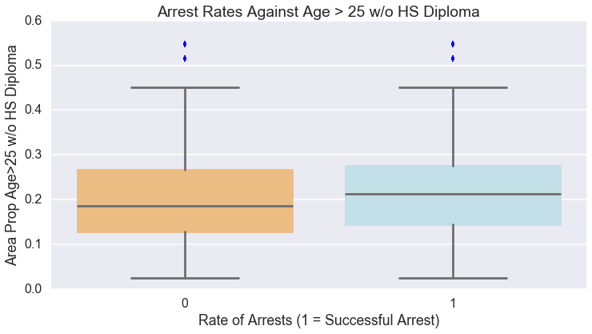

```python
sns.boxplot(x = 'Arrest', y = 'Area Prop Age>25 w/o HS Diploma', data = demos_arrest, palette="RdYlBu")

plt.title('Arrest Rates Against Age > 25 w/o HS Diploma')
plt.xlabel('Rate of Arrests (1 = Successful Arrest)')
plt.show();
```

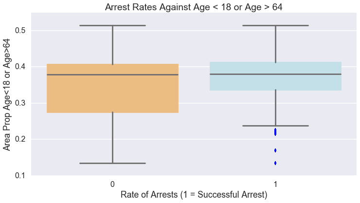

```python
sns.boxplot(x = 'Arrest', y = 'Area Prop Age<18 or Age>64', data = demos_arrest, palette="RdYlBu")

plt.title('Arrest Rates Against Age < 18 or Age > 64')
plt.xlabel('Rate of Arrests (1 = Successful Arrest)')
plt.show();
```

These box plots really appear to be in line with the findings of our L1 Regularization model! The random forest model, on the other hand, doesn't appear to be accurate at all to the realities of our feature importance.

### High Crime Areas

Critically important to decisions regarding the allocation of anti-crime resources is locating "hot spots" for crime.

Knowing what makes those areas different from low-crime areas is important both for crime prevention and for enacting indirect solution, like reducing poverty or unemployment.

Below, we attempt to determine what makes the highest crime areas different from the lowest crime areas.

```python
crime.head()
```

|  | Unnamed: 0 | ID | Date | Day of Week | Primary Type | Description | Location Description | Arrest | Domestic | Latitude | Longitude | Community Area | CA Name | Area Prop Housing Crowded | Area Prop Households Below Poverty | Area Prop Age>16 Unemployed | Area Prop Age>25 w/o HS Diploma | Area Prop Age<18 or Age>64 | Area Per Capita Income | Hardship Index | CST | Max TempF | Min TempF | Max Dew PtF | Min DewPtF | Max Humidity | Min Humidity | Max Sea Lvl PresIn | Min Sea Lvl PresIn | … |
| --- | --- | --- | --- | --- | --- | --- | --- | --- | --- | --- | --- | --- | --- | --- | --- | --- | --- | --- | --- | --- | --- | --- | --- | --- | --- | --- | --- | --- | --- | --- |
| 0 | 0 | 8421479 | 2012-01-01 | Sunday | BATTERY | SIMPLE | STREET | 0 | 0 | 41.814873 | -87.688296 | 58 | Brighton Park | 0.144 | 0.236 | 0.139 | 0.451 | 0.393 | 13089 | 84 | 2012-01-01 | 44 | 29 | 36 | 16 | 85 | 56 | 30.07 | 29.52 | … |
| 1 | 1 | 8421469 | 2012-01-01 | Sunday | BATTERY | SIMPLE | HOTEL/MOTEL | 1 | 0 | 41.872709 | -87.624188 | 32 | Loop | 0.015 | 0.147 | 0.057 | 0.031 | 0.135 | 65526 | 3 | 2012-01-01 | 44 | 29 | 36 | 16 | 85 | 56 | 30.07 | 29.52 | … |
| 2 | 2 | 8421462 | 2012-01-01 | Sunday | BATTERY | SIMPLE | APARTMENT | 1 | 0 | 41.765425 | -87.578129 | 43 | South Shore | 0.028 | 0.311 | 0.200 | 0.140 | 0.357 | 19398 | 55 | 2012-01-01 | 44 | 29 | 36 | 16 | 85 | 56 | 30.07 | 29.52 | … |
| 3 | 3 | 8421444 | 2012-01-01 | Sunday | BURGLARY | HOME INVASION | APARTMENT | 0 | 0 | 41.732850 | -87.555470 | 46 | South Chicago | 0.047 | 0.298 | 0.197 | 0.266 | 0.411 | 16579 | 75 | 2012-01-01 | 44 | 29 | 36 | 16 | 85 | 56 | 30.07 | 29.52 | … |
| 4 | 4 | 8421811 | 2012-01-01 | Sunday | CRIM SEXUAL ASSAULT | NON-AGGRAVATED | STREET | 0 | 0 | 41.872709 | -87.624188 | 32 | Loop | 0.015 | 0.147 | 0.057 | 0.031 | 0.135 | 65526 | 3 | 2012-01-01 | 44 | 29 | 36 | 16 | 85 | 56 | 30.07 | 29.52 | … |

```python
pd.options.display.max_rows = 10
crime['CA Name'].value_counts()
```

```
Austin             19208
South Shore        10343
Humboldt park      10106
Near North Side    10006
North Lawndale      9322
                   ...
Hegewisch            625
Mount Greenwood      599
Forest Glen          528
Burnside             472
Edison Park          270
Name: CA Name, dtype: int64
```

Austin seems to out-perform all other areas in Chicago by a wide margin.

For perspective, the following demographic plots indicate where the top two crime areas (Austin and South Shore) and the bottom two crime areas (Burnside and Edison Park) lay within the over-all distribution for demographic measures.

```python
crimeb = crime.dropna()
austin = crimeb[crimeb['CA Name'] == 'Austin']
south = crimeb[crimeb['CA Name'] == 'South Shore']
burnside = crimeb[crimeb['CA Name'] == 'Burnside']
edison = crimeb[crimeb['CA Name'] == 'Edison Park']
forest = crimeb[crimeb['CA Name'] == 'Forest Glen']
austin.index = range(0,len(austin))
south.index = range(0,len(south))
burnside.index = range(0,len(burnside))
edison.index = range(0,len(edison))
forest.index = range(0,len(forest))
austin.head()
```

|  | Unnamed: 0 | ID | Date | Day of Week | Primary Type | Description | Location Description | Arrest | Domestic | Latitude | Longitude | Community Area | CA Name | Area Prop Housing Crowded | Area Prop Households Below Poverty | Area Prop Age>16 Unemployed | Area Prop Age>25 w/o HS Diploma | Area Prop Age<18 or Age>64 | Area Per Capita Income | Hardship Index | CST | Max TempF | Min TempF | Max Dew PtF | Min DewPtF | Max Humidity | Min Humidity | Max Sea Lvl PresIn | Min Sea Lvl PresIn | … |
| --- | --- | --- | --- | --- | --- | --- | --- | --- | --- | --- | --- | --- | --- | --- | --- | --- | --- | --- | --- | --- | --- | --- | --- | --- | --- | --- | --- | --- | --- | --- |
| 0 | 30 | 9142576 | 2012-01-01 | Sunday | THEFT | FROM BUILDING | SCHOOL, PUBLIC, BUILDING | 0 | 0 | 41.884856 | -87.763346 | 25 | Austin | 0.063 | 0.286 | 0.226 | 0.244 | 0.379 | 15957 | 73 | 2012-01-01 | 44 | 29 | 36 | 16 | 85 | 56 | 30.07 | 29.52 | … |
| 1 | 38 | 8421450 | 2012-01-01 | Sunday | WEAPONS VIOLATION | UNLAWFUL POSS OF HANDGUN | STREET | 1 | 0 | 41.882245 | -87.747792 | 25 | Austin | 0.063 | 0.286 | 0.226 | 0.244 | 0.379 | 15957 | 73 | 2012-01-01 | 44 | 29 | 36 | 16 | 85 | 56 | 30.07 | 29.52 | … |
| 2 | 43 | 8421455 | 2012-01-01 | Sunday | WEAPONS VIOLATION | UNLAWFUL POSS OF HANDGUN | STREET | 1 | 0 | 41.908461 | -87.773151 | 25 | Austin | 0.063 | 0.286 | 0.226 | 0.244 | 0.379 | 15957 | 73 | 2012-01-01 | 44 | 29 | 36 | 16 | 85 | 56 | 30.07 | 29.52 | … |
| 3 | 45 | 8421434 | 2012-01-01 | Sunday | BATTERY | SIMPLE | APARTMENT | 0 | 1 | 41.874129 | -87.743335 | 25 | Austin | 0.063 | 0.286 | 0.226 | 0.244 | 0.379 | 15957 | 73 | 2012-01-01 | 44 | 29 | 36 | 16 | 85 | 56 | 30.07 | 29.52 | … |
| 4 | 53 | 8421415 | 2012-01-01 | Sunday | NARCOTICS | POSS: CANNABIS 30GMS OR LESS | STREET | 1 | 0 | 41.902294 | -87.751572 | 25 | Austin | 0.063 | 0.286 | 0.226 | 0.244 | 0.379 | 15957 | 73 | 2012-01-01 | 44 | 29 | 36 | 16 | 85 | 56 | 30.07 | 29.52 | … |

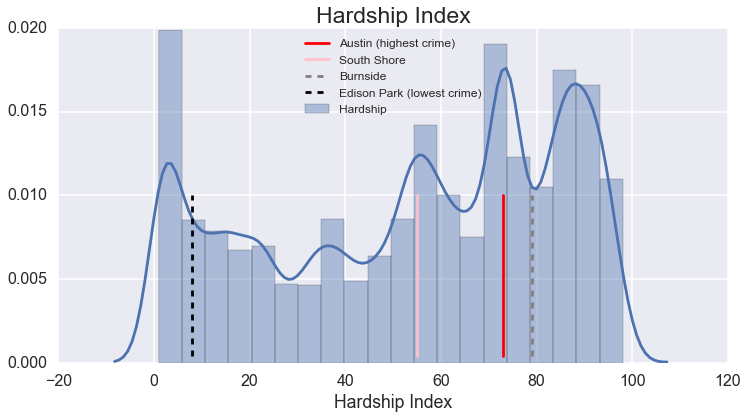

```python
sns.distplot(crimeb['Hardship Index'], bins=20, label='Hardship')
plt.axvline(x=austin['Hardship Index'][0], ymin=0.02, ymax=0.5, hold=None, color = 'r', label = 'Austin (highest crime)')
plt.axvline(x=south['Hardship Index'][0], ymin=0.02, ymax=0.5, hold=None, color = 'pink', label = 'South Shore')
plt.axvline(x=burnside['Hardship Index'][0], ymin=0.02, ymax=0.5, hold=None, color = 'grey', linestyle= '--', label = 'Burnside')
plt.axvline(x=edison['Hardship Index'][0], ymin=0.02, ymax=0.5, hold=None, color = 'black', linestyle= '--', label = 'Edison Park (lowest crime)')

plt.title("Hardship Index", fontsize= 23)
plt.legend(fontsize = 12, loc='upper center');
```

Austin is on the higher side of the distribution of the Hardship Index and Edison Park is very much on the lower end. South Shore is closer to the middle. Burnsides, with the second lowest number of crimes has a higher Hardship index than either Austin or South Shore. This provides some evidence that Hardship Index values are associated with total crimes. Burnside seems to be an outlier with this metric.